# Explorative Datenanalyse der WW2-Flugangriffs-Daten von Gruppe Rosa

Florian Stammwitz, Jakob Wittann, Anne Gossing, Robert Stelzle

Erstellt im Conda Environment `Class05`

## Vorbereitung

**Import statements**

```python
import numpy as np
import pandas as pd
import matplotlib.pyplot as plt
import seaborn as sns
%matplotlib inline
```

**Load data set**

```python
import pickle
gdf_europe = pickle.load( open( "../data/gdf_europe.p", "rb" ) )
europe = pickle.load(open( "../data/europe.p", "rb" ) )
germany = pickle.load(open("../data/germany.p", "rb"))
gdf_germany = pickle.load(open("../data/gdf_germany.p", "rb"))
```

```python
df_airpl = gdf_europe.copy()
type(df_airpl)
```

```
geopandas.geodataframe.GeoDataFrame
```

```python
df_airpl = pd.DataFrame(df_airpl.drop(columns='geometry')) ## Das Plotten vom GeoDataFrame war z.T. echt nervig. Deshalb jetzt wieder ein normales DF.
type(df_airpl)
```

```
pandas.core.frame.DataFrame
```

## Das Gewicht der Bomben je nach Fliegertyp

### Erste univariate Betrachtungen der relavanten Variablen

#### Gewicht der Bomben

Im Datensatz finden sich zwei Variablen: `High Explosives Weight (Tons)` sowie `Total Weight (Tons)`. Die Vermutung wäre, dass das Total Weight auch das Gewicht der Flugzeuge miteinbeziehen soll. Oftmals finden sich jedoch identische Werte, was an der Datenqualität zweifeln lässt. Im folgenden wird die Variable `High Explosives Weight (Tons)` genutzt.

```python
df_airpl[["High Explosives Weight (Tons)" , "Total Weight (Tons)"]].sample(10, random_state=2019) ## random_state legt den Seed fest. so hab ich jedes mal das gleiche  Sample.
```

|  | High Explosives Weight (Tons) | Total Weight (Tons) |
| --- | --- | --- |
| 52562 | 1.0 | 1.0 |
| 76379 | 17.0 | 34.0 |
| 59262 | 53.0 | 53.0 |
| 154329 | NaN | NaN |
| 72026 | 2.0 | 2.0 |
| 74821 | 24.0 | 24.0 |
| 106804 | NaN | 33.0 |
| 143407 | 2.0 | 2.0 |
| 178082 | 41.0 | 41.0 |
| 75104 | 1.0 | 1.0 |

Das maximale angegebene Bombengewicht im Datensatz beträgt 999T. Zumindest für ein einzelnes Flugzeug erscheint das zu viel. Dazu jedoch später mehr.

```python
df_airpl["High Explosives Weight (Tons)"].describe()
```

```
count    101482.000000
mean         29.979849
std          58.430648
min           0.000000
25%           3.000000
50%          18.000000
75%          36.000000
max         999.000000
Name: High Explosives Weight (Tons), dtype: float64
```

Für die wenigsten Missionen ist ein Waffengewicht von mehr als ~150T angegeben.

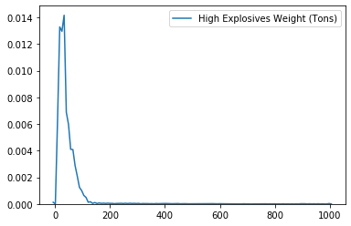

```python
sns.kdeplot(data=df_airpl["High Explosives Weight (Tons)"])
```

#### Anzahl der an einer Mission beteiligten Flugzeuge

Im Datensatz findet sich die Variable `Attacking Aircraft`. Vermutlich gibt diese gibt die Zahl der an einer Mission beteiligten Flugzeuge an.  
Im Schnitt waren -wenn ich die Variable richtig verstehe- knapp 13 Flugzeuge an Missionen beteiligt.

```python
df_airpl["Attacking Aircraft"].describe()
```

```
count    73628.000000
mean        13.003355
std         12.653974
min          0.000000
25%          2.000000
50%         11.000000
75%         18.000000
max        332.000000
Name: Attacking Aircraft, dtype: float64
```

Für nur die wenigsten Missionen sind mehr als 50 beteiligte Flugzeuge gelistet.

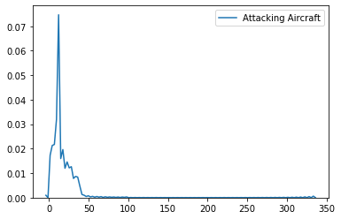

```python
sns.kdeplot(data=df_airpl["Attacking Aircraft"])
```

#### Flugzeugtypen

```python
df_airpl["Aircraft Series"].unique()
```

```
array(['A36', 'LGT', 'B17', 'GB17', 'HVY', 'B26', 'B25', 'A20', 'GB24',
       'B24', 'OB24', 'SB24', 'A26', 'LIB', 'OB17', 'HALI', 'SB17',
       'HAMP', '0B24', 'BLEN', 'WELL', 'MED', '0B17', 'WHIT', 'STIR',
       'ALBA', 'BATT', 'MANC', 'SWORD', 'AUDA', 'VALE', 'MARY', 'BEAU',
       'HURR', 'TOM', nan, 'BEAUF'], dtype=object)
```

```python
df_airpl["Aircraft Series"].unique().shape
```

```
(37,)
```

Es finden sich zwei Doppelungen: Es gibt die Typen `OB24` und `0B24` sowie `OB17` und `0B17`. Hier liegt es nahe, dass es sich hier um denselben Flugzeugtyp handelt, weshalb die Kategorien zusammengefasst werden:

```python
df_airpl["Aircraft Series"] = df_airpl["Aircraft Series"].str.replace("OB17", "0B17").str.replace("OB24", "0B24")
```

Hier wie oft die verschiedenen Typen zum Einsatz kamen:

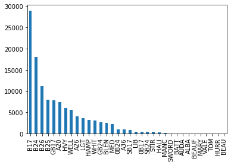

```python
df_airpl["Aircraft Series"].value_counts().plot.bar()
```

### Waffengewicht pro Flugzeug

Hier ein Scatter-Plot des Waffengewichts einer Mission über der Zahl der beteiligten Flugzeuge:

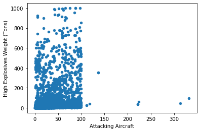

```python
df_airpl.plot.scatter(x="Attacking Aircraft", y="High Explosives Weight (Tons)")
```

Da uns interessiert welcher Flugzeugtyp die größte Bombenlast trug und nicht welche Flugzeuge die Missionen mit dem größten Waffengewicht durchgeführt haben, wird das Waffengewicht der Mission durch die Zahl der beteiligten Flugzeuge geteilt:

```python
df_airpl["Explosive Weight Per Plane"] = df_airpl["High Explosives Weight (Tons)"] / df_airpl["Attacking Aircraft"]
```

Hier das Histogram der Verteilung des durchschnittlichen Waffengewichts pro Flugzeug:

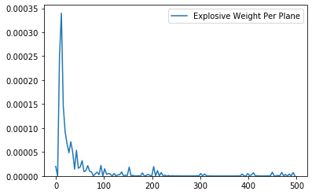

```python
sns.kdeplot(data=df_airpl["Explosive Weight Per Plane"])
```

### Waffengewicht nach Flugzeugtyp

Hier ein Barplot für das durchschnittliche (über alle Missionen) Waffengewicht pro Flugzeug für die verschiedenen Flugzeugtypen:

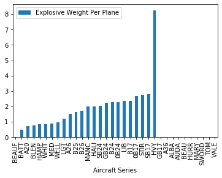

```python
mean_bombengewicht = df_airpl[["Aircraft Series", "Explosive Weight Per Plane"]].groupby("Aircraft Series").mean().sort_values(by="Explosive Weight Per Plane")
mean_bombengewicht.plot.bar()
```

Diesen Werten nach trägt der Bomber des Typs HVY die schwersten Bomben. Da ich im Internet jedoch kein Flugzeug dieses Typennamens gefunden habe und da dieser Wert derart stark von den restlichen Werten abweicht, ist an diesem Ergebnis zu zweifeln.

### Maximales Waffengewicht pro Flugzeug

Da ich wie oben beschrieben z.T. an den im Datensatz abgetragenen Werten zweifle habe ich eine kurze Internetrechersche durchgeführt. Meinen Recherschen nach ist die Russische [Tupolev Tu-160](https://en.wikipedia.org/wiki/Tupolev_Tu-160) der schwerste und soweit ich das verstehe auch mit der meisten Bombenlast beladbare Bomber der Welt (skurrilerweise listet die Wikipedia hier z.T. Guinness World Records als Quelle).  
Die in den 1980er Jahren entwickelte Tupolev Tu-160 kann maximal mit 40 Tonnen an Waffen beladen werden. Obwohl anzunehmen ist, dass die im zweiten Weltkrieg eingesetzten Flugzeuge eine geringere Waffenlast als die Tu-160 hatten, beschränke ich die Range der Waffenlast pro Flugzeug in der folgenden Analyse auf bis zu 40 Tonnen, da ich für die in WW2 eingesetzten Flugzeuge keine belastbaren Werte gefunden habe und da ich dem Ergebnis dieser Analyse natürlich nicht vorgreifen will.

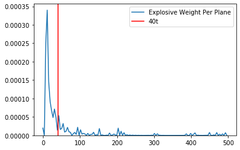

```python
sns.kdeplot(data=df_airpl["Explosive Weight Per Plane"])
plt.axvline(x=40, color="red", label="40t")
plt.legend()
```

Alle Fälle oberhalb der Geraden bei 40t/Flugzeug in der folgenden Abbildung werden also aus der Analyse ausgeschlossen.

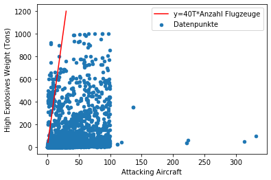

```python
x = np.linspace(1,30,110)
df_airpl.plot.scatter(x="Attacking Aircraft", y="High Explosives Weight (Tons)", label="Datenpunkte")
plt.legend()
plt.plot(x,40*x+0, '-r', label='y=40T*Anzahl Flugzeuge')
plt.legend()
```

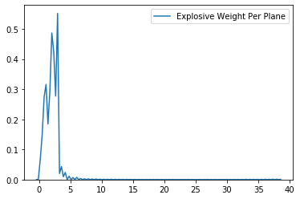

```python
sns.kdeplot(data=df_airpl["Explosive Weight Per Plane"].loc[(df_airpl["Explosive Weight Per Plane"]<40)])
```

Mit diesem beschränkten Wertebereich ergeben sich die folgenden durchschnittlichen Beladungswerte der verschiedenen Flugzeuge:

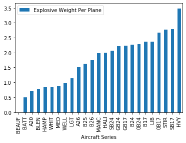

```python
mean_bombengewicht_max40 = df_airpl[["Aircraft Series", "Explosive Weight Per Plane"]].loc[(df_airpl["Explosive Weight Per Plane"]<40)].groupby("Aircraft Series").mean().sort_values(by="Explosive Weight Per Plane")
mean_bombengewicht_max40.plot.bar()
```

Der von mir nicht identifizierte Typ HVY belegt weiterhin den ersten Rang, jetzt jedoch mit einem deutlich weniger abweichenden Schnitt als zuvor.

[figure not shown]

Source: [Wikimedia Commons](https://commons.wikimedia.org/wiki/File:B17-F-45-VE.jpg)

Der drittschwerste Flugzeugtyp ist die STIR. Vermutlich handelt es sich hierbei um die [Short Stirling](https://de.wikipedia.org/wiki/Short_Stirling).

[figure not shown]

Source: [Wikimedia Commons](https://commons.wikimedia.org/wiki/File:Short_Stirling_bomber_N6101.jpg)

Auf den Rängen 5, 7 und 8 finden sich Flieger der Typen LIB, 0B24 und B24. Hierbei handelt es sich wohl um die [Consolidated B-24](https://de.wikipedia.org/wiki/Consolidated_B-24), genannt "Liberator".

[figure not shown]

Source: [Wikimedia Commons](https://commons.wikimedia.org/wiki/File:B-24M-20-CO_USAAF.jpg)

Abschließend hier noch Kennziffern zum durchschnittlichen Waffengewicht aller gelisteten Flugzeugtypen:

```python
df_airpl[["Aircraft Series", "Explosive Weight Per Plane"]].loc[(df_airpl["Explosive Weight Per Plane"]<40)].groupby("Aircraft Series").describe()
```

| Aircraft Series | Explosive Weight Per Plane count | Explosive Weight Per Plane mean | Explosive Weight Per Plane std | Explosive Weight Per Plane min | Explosive Weight Per Plane 25% | Explosive Weight Per Plane 50% | Explosive Weight Per Plane 75% | Explosive Weight Per Plane max |
| --- | --- | --- | --- | --- | --- | --- | --- | --- |
| 0B17 | 409.0 | 2.671760 | 0.754908 | 0.500000 | 2.320000 | 2.964286 | 3.000000 | 10.000000 |
| 0B24 | 902.0 | 2.275344 | 0.747913 | 0.117647 | 2.000000 | 2.322581 | 2.500000 | 17.400000 |
| A20 | 2969.0 | 0.715965 | 0.575843 | 0.083333 | 0.166667 | 0.750000 | 1.000000 | 3.000000 |
| A26 | 886.0 | 1.511287 | 0.501283 | 0.500000 | 1.000000 | 2.000000 | 2.000000 | 2.000000 |
| B17 | 20791.0 | 2.369778 | 0.869820 | 0.051282 | 2.000000 | 2.500000 | 3.000000 | 33.000000 |
| B24 | 12979.0 | 2.262060 | 0.935874 | 0.000000 | 1.947368 | 2.388889 | 2.750000 | 31.000000 |
| B25 | 3746.0 | 1.628362 | 0.592536 | 0.000000 | 1.375000 | 1.833333 | 2.000000 | 8.666667 |
| B26 | 1777.0 | 1.736994 | 0.516762 | 0.045455 | 1.500000 | 1.944444 | 2.000000 | 8.000000 |
| BATT | 12.0 | 0.494312 | 0.254588 | 0.181818 | 0.293182 | 0.450000 | 0.666667 | 1.000000 |
| BEAUF | 1.0 | 0.000000 | NaN | 0.000000 | 0.000000 | 0.000000 | 0.000000 | 0.000000 |
| BLEN | 976.0 | 0.778982 | 0.660520 | 0.033333 | 0.500000 | 0.666667 | 1.000000 | 10.333333 |
| GB17 | 5341.0 | 2.236181 | 0.807190 | 0.051282 | 1.653846 | 2.466667 | 2.916667 | 22.500000 |
| GB24 | 1830.0 | 2.220376 | 1.087351 | 0.025000 | 1.500000 | 2.454545 | 3.000000 | 23.750000 |
| HALI | 125.0 | 1.990756 | 3.356582 | 0.285714 | 1.333333 | 1.666667 | 2.000000 | 38.000000 |
| HAMP | 1746.0 | 0.844235 | 0.360324 | 0.025000 | 0.666667 | 1.000000 | 1.000000 | 8.000000 |
| HVY | 2147.0 | 3.483304 | 4.970827 | 0.021978 | 0.939640 | 2.000000 | 4.000000 | 38.125000 |
| LGT | 2599.0 | 1.142826 | 1.170714 | 0.034483 | 0.800000 | 1.000000 | 1.046537 | 31.000000 |
| LIB | 18.0 | 2.373651 | 0.827226 | 1.000000 | 1.635673 | 3.000000 | 3.000000 | 3.000000 |
| MANC | 106.0 | 1.984603 | 0.844470 | 0.200000 | 1.200000 | 2.000000 | 2.666667 | 4.000000 |
| MED | 890.0 | 0.886285 | 0.761682 | 0.025316 | 0.333333 | 0.750000 | 1.000000 | 8.500000 |
| SB17 | 5.0 | 2.790909 | 0.286760 | 2.454545 | 2.500000 | 3.000000 | 3.000000 | 3.000000 |
| SB24 | 3.0 | 2.059561 | 0.636888 | 1.454545 | 1.727273 | 2.000000 | 2.362069 | 2.724138 |
| STIR | 220.0 | 2.771650 | 1.320512 | 0.166667 | 2.107143 | 3.000000 | 3.000000 | 10.000000 |
| WELL | 2692.0 | 0.980176 | 0.534401 | 0.019231 | 0.666667 | 1.000000 | 1.000000 | 5.000000 |
| WHIT | 1348.0 | 0.844348 | 0.409235 | 0.052632 | 0.500000 | 1.000000 | 1.000000 | 9.615385 |

## Analyse Flughöhe

Im Durchschnitt werden die Operationen in einer höhe von fast 5,5km durchgeführt:

```python
print(df_airpl["Altitude (meters)"].mean())
```

```
5459.724502913104
```

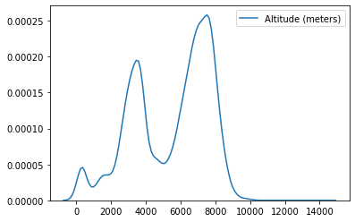

```python
sns.kdeplot(data=df_airpl["Altitude (meters)"])
```

Der Density Plot vermittelt eine grobe Vorstellung von der Verteilung der Flughöhe der an den Einsätzen beteiligten Flugzeuge. Dabei wurde die Variable `Altitude Meters` geplottet. Aus statistischer Sicht spiegelt das Integral unterhalb des Grafens die genaue Verteilung wieder. Dabei fällt die Zweigipfligkeit der Verteilung auf, wobei die meisten Flugzeuge entweder eine Flughöhe zwischen 2100 und 4000 bzw. zwischen 6000 und 8000 Metern besaßen. Vermutlich spiegelt dies Kurz- und Langstreckenflugzeuge wieder, die mit unterschiedlichen Höhen operierten.

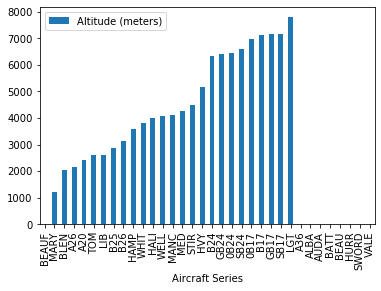

```python
mean_hoehe=df_airpl[["Aircraft Series", "Altitude (meters)"]].groupby("Aircraft Series").mean().sort_values(by="Altitude (meters)")
mean_hoehe.plot.bar()
```

Das Histogram/Stabdiagram spiegelt die unterschiedlichen Flugzeugtypen sortiert nach der Flughöhe wieder. Die höchste Flughöhe erreichten dabei die britischen LGT und die amerikanischen Flugzeuge des Typs SB17.

### Höhe je nach Waffengewicht

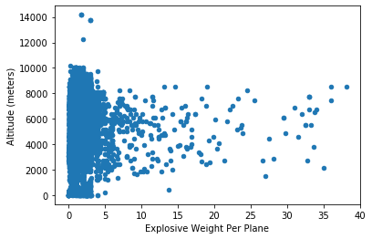

```python
hoehe_gewicht = df_airpl[["Altitude (meters)", "Explosive Weight Per Plane"]].loc[(df_airpl["Explosive Weight Per Plane"]<40)]
hoehe_gewicht.plot.scatter(x="Explosive Weight Per Plane", y="Altitude (meters)")
```

Der Scatterplot zeigt, dass es keinen klaren systematischen Zusammenhang zwischen der Flughöhe und dem Waffengewicht der Flugzeuge gab. Eine in den Scatterplot gelegte lineare Regressionsgerade würde wahrscheinlich keinen signifikanten Anstieg aufweisen.

## Flugzeugmodelle der alliierten Streitkräfte, Einsatzorte und Einsatzjahre

Zur Analyse werden aus dem Datensatz die Variablen `Country`, `Aircraft Series`, `Target Latitude`, `Target Longitude` und `Year` herangezogen.

```python
df_airpl_gdf = gdf_europe.copy()  ## Hier brauchen wir wieder das geodataframe
```

### Alliierte Streitkräfte

```python
allies = df_airpl_gdf['Country'].unique()
print(allies)
```

```
['USA' 'GREAT BRITAIN' nan 'SOUTH AFRICA' 'AUSTRALIA']
```

Der Datensatz enthält sowohl Informationen zu Einsätzen von Großbritanien, USA, Südafrika, und Australien, als auch über Einsätze, bei denen die Leitung unbekannt ist.

### Einsatzjahre

```python
years = df_airpl_gdf['year'].unique()
years.sort()
print(years)
```

```
[1939 1940 1941 1942 1943 1944 1945]
```

Die Einsätze fanden in den Jahren zwischen 1939 und 1945 statt.

### Einsätze über Europa und Nordafrika

```python
# Liste der Flugzeugtypen
# Eingrenzung auf A36, LGT, B17
series = df_airpl_gdf['Aircraft Series'].unique()
series = ['B17', 'HVY','LGT']
```

```python
# Funktion zum Plotten der Flugzeugeinsätze über Europa
def plot_airplane_type_over_europe(gdf, airplane,
                                   years=years,
                                   kdp=False, aoi=europe):
    fig = plt.figure(figsize=(16,12))
    for e, y in enumerate(years):
        _gdf = gdf.loc[(gdf["year"]==y) & (gdf["Aircraft Series"]==airplane)].copy()
        _gdf.Country.replace(np.nan, "unknown", inplace=True)
        ax = fig.add_subplot(4,2,e+1)
        ax.set_aspect('equal')
        aoi.plot(ax=ax, facecolor='lightgray', edgecolor="white")
        if _gdf.shape[0] > 2:
            if kdp:
                sns.kdeplot(_gdf['Target Longitude'], _gdf['Target Latitude'],
                            cmap="viridis", shade=True, shade_lowest=False, bw=0.25, ax=ax)
            else:
                _gdf.plot(ax=ax, marker='o', cmap='Set1', categorical=True,
                          column='Country', legend=True, markersize=5, alpha=1)
        ax.set_title("Year: " + str(y), size=16)
    plt.tight_layout()
    plt.suptitle("Einsätze von Flugzeugtyp {}".format(airplane), size=22)
    plt.subplots_adjust(top=0.92)
    return fig, ax
```

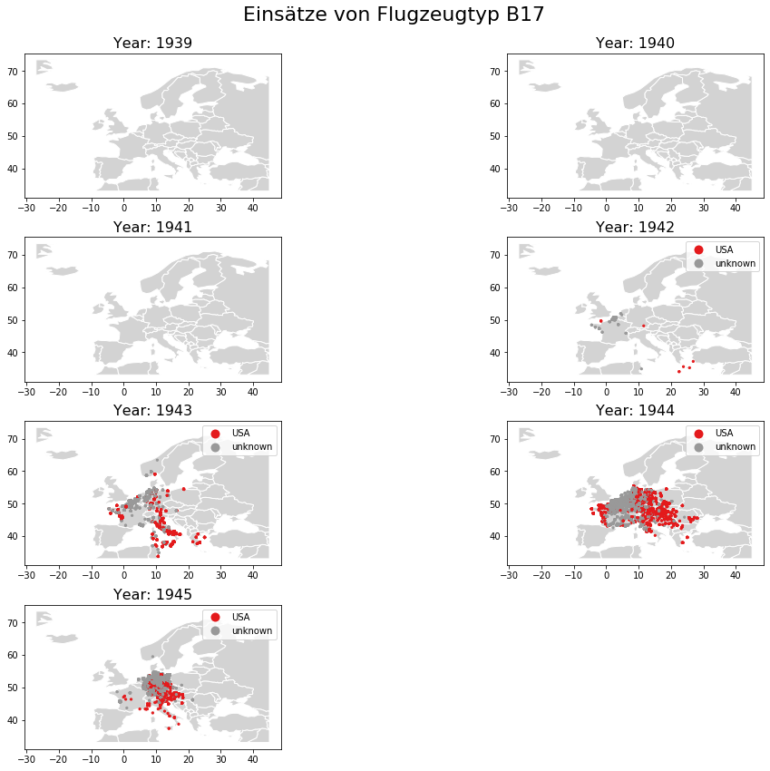

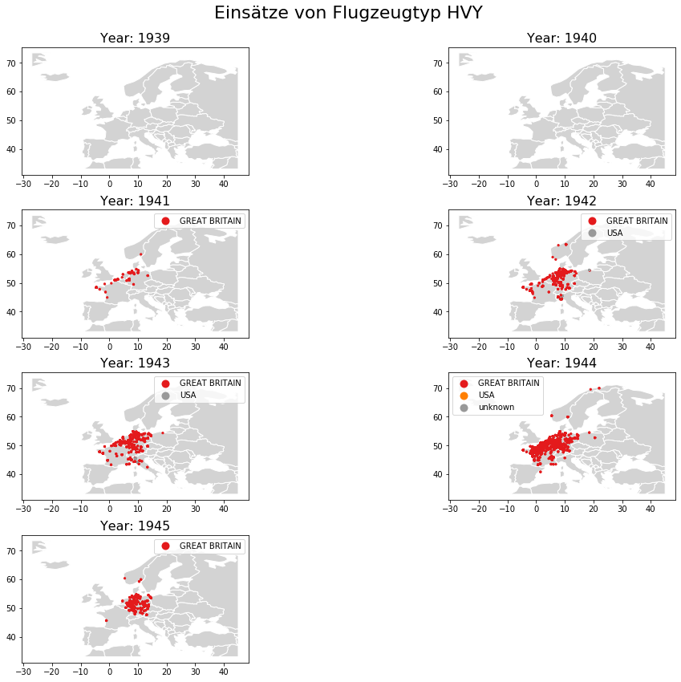

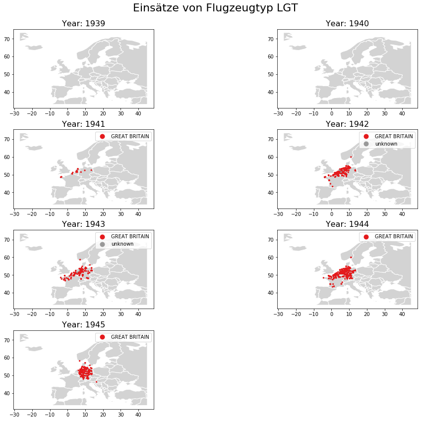

```python
# Plots der Einsätze für alle Flugzeugtypen
for model in series:
    plot_airplane_type_over_europe(df_airpl_gdf, airplane=model, kdp=False)
```

## Werden die gleichen Flugzeugtypen in Europa und in Asien eingesetzt?

Aufbereiten der Daten. `df_airpl_asia` ist die Differenz aus dem gesamten Datensatz und den Operationen in Europa. Alle übriggebliebenen Operationen fanden in Asien statt.

```python
df_raw = pd.read_csv("../data/operations.csv", low_memory=False)
df_clean = df_raw.copy()
df_clean.loc[((df_clean['Target Longitude'] > 180) |
                    (df_clean['Target Longitude'] < -180) |
                    (df_clean['Target Latitude'] > 90 )|
                    (df_clean['Target Latitude'] < -90)),
                   ['Target Longitude', 'Target Latitude']] = np.nan
```

```python
df_clean["Aircraft Series"] = df_clean["Aircraft Series"].str.replace("OB17", "0B17").str.replace("OB24", "0B24")
#df_airpl["Aircraft Series"] = df_airpl["Aircraft Series"].str.replace("OB17", "0B17").str.replace("OB24", "0B24")  # Wurde für Europa oben schon gemacht
```

```python
df_airpl_asia = (df_clean['Aircraft Series'].value_counts(sort=False) - df_airpl['Aircraft Series'].value_counts(sort=False) )
```

Nun werden die Daten für Europa und Asien in je einem Säulendiagramm dargestellt. Damit die Werte besser verglichen werden können, wurde das Diagramm für Asien auf die Größe des Europa-Diagramms skaliert.

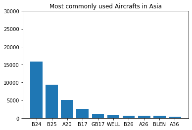

```python
df_airpl_asia_sorted = df_airpl_asia.sort_values(ascending = False)[:10]
plt.bar(df_airpl_asia_sorted.index, df_airpl_asia_sorted.values )
plt.title('Most commonly used Aircrafts in Asia')
plt.ylim(0, 30000)
plt.show()
```

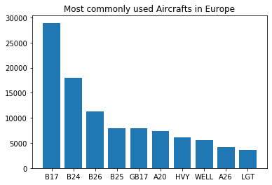

```python
df_airpl_sorted = df_airpl['Aircraft Series'].value_counts()[:10]
plt.bar(df_airpl_sorted.index, df_airpl_sorted.values )
plt.title('Most commonly used Aircrafts in Europe')
plt.show()
```

Eine Auffäligkeit ist, dass der Flugzeugtyp B17 zwar sehr viel in Europa verwendet worden ist, allerdings kaum in Asien. Im folgendem wurden alle Einsatzorte von Flugzeugen des Types B17 auf der Weltkarte dargestellt. Dies unterschreicht, das der Haupteinsatzort dieses Types in Europa war.

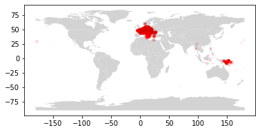

```python
import geopandas as gpd
from shapely.geometry import Point
df_b17 = df_clean.loc[df_clean['Aircraft Series'] == 'B17']
geometry = [Point(xy) for xy in zip(df_b17['Target Longitude'], df_b17['Target Latitude'])]
gdf = gpd.GeoDataFrame(df_b17, geometry=geometry)
gdf.crs = {'init' :'epsg:4326'}
world = gpd.read_file(gpd.datasets.get_path('naturalearth_lowres'))
base = world.plot(facecolor='lightgray')
gdf.plot(ax=base, marker='o', color='red', markersize=10, alpha=0.01);
```